# angling_GT

2026-04-02

# 調査日(date)

```
## # A tibble: 6 × 3
##   date             n  prop
##   <ord>        <int> <dbl>
## 1 9月27日_プレ    24  0.24
## 2 10月4日         23  0.23
## 3 10月5日         20  0.2
## 4 10月17日        19  0.19
## 5 10月19日         1  0.01
## 6 10月24日        11  0.11
```

# 調査地(survey_area)

```
## # A tibble: 3 × 3
##   survey_area     n  prop
##   <chr>       <int> <dbl>
## 1 モヨロ         10  0.1
## 2 北浜           34  0.35
## 3 鱒浦           54  0.55
```

鱒浦でのサンプルが半分以上。モヨロは10％しかない。

```
## # A tibble: 7 × 4
##   date         survey_area     n  prop
##   <ord>        <chr>       <int> <dbl>
## 1 9月27日_プレ モヨロ          9  0.09
## 2 9月27日_プレ 鱒浦           15  0.15
## 3 10月4日      北浜           23  0.23
## 4 10月5日      鱒浦           20  0.2
## 5 10月17日     鱒浦           19  0.19
## 6 10月19日     モヨロ          1  0.01
## 7 10月24日     北浜           11  0.11
```

調査日×調査地の度数分布。

# 性別(v1_sex)

```
## # A tibble: 3 × 3
##   v1_sex     n  prop
##   <ord>  <int> <dbl>
## 1 男性      91  0.93
## 2 女性       6  0.06
## 3 <NA>       1  0.01
```

ほとんど男ばかり。

```
## # A tibble: 6 × 4
##   v1_sex survey_area     n  prop
##   <ord>  <chr>       <int> <dbl>
## 1 男性   モヨロ         10  0.1
## 2 男性   北浜           32  0.33
## 3 男性   鱒浦           49  0.5
## 4 女性   北浜            2  0.02
## 5 女性   鱒浦            4  0.04
## 6 <NA>   鱒浦            1  0.01
```

女性がどこに多いかというのは今回のデータではよくわからない。

# 世代(v2_gen)

```
## # A tibble: 8 × 3
##   v2_gen       n  prop
##   <chr>    <int> <dbl>
## 1 20代         3  0.03
## 2 30代         7  0.07
## 3 40代        13  0.13
## 4 50代        27  0.28
## 5 60代        16  0.16
## 6 70代        20  0.2
## 7 80代以上    11  0.11
## 8 <NA>         1  0.01
```

50代と70代が多い。

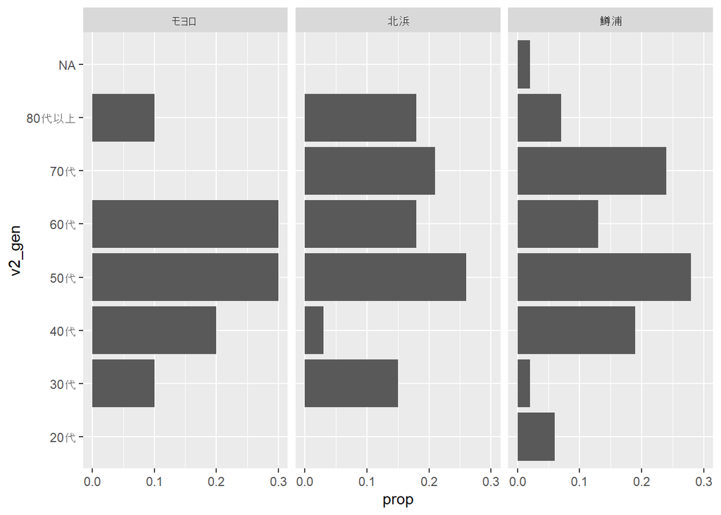

各調査地のサンプルの偏りを考慮すると、調査地ごとで分布に特に違いがあるようには見えない。

# 居住地(v3_residence)

```
## # A tibble: 3 × 3
##   v3_residence     n  prop
##   <ord>        <int> <dbl>
## 1 網走市内        13  0.13
## 2 道内            84  0.86
## 3 <NA>             1  0.01
```

道外はゼロ。また、市外から来ている人が9割近い。

# 釣り歴(v4_fishing_experience_years)

```
## # A tibble: 5 × 3
##   v4_fishing_experience_years     n  prop
##   <ord>                       <int> <dbl>
## 1 5年未満                        12  0.12
## 2 5年以上10年未満                17  0.17
## 3 10年以上20年未満               15  0.15
## 4 20年以上                       53  0.54
## 5 <NA>                            1  0.01
```

20年以上が半数以上。

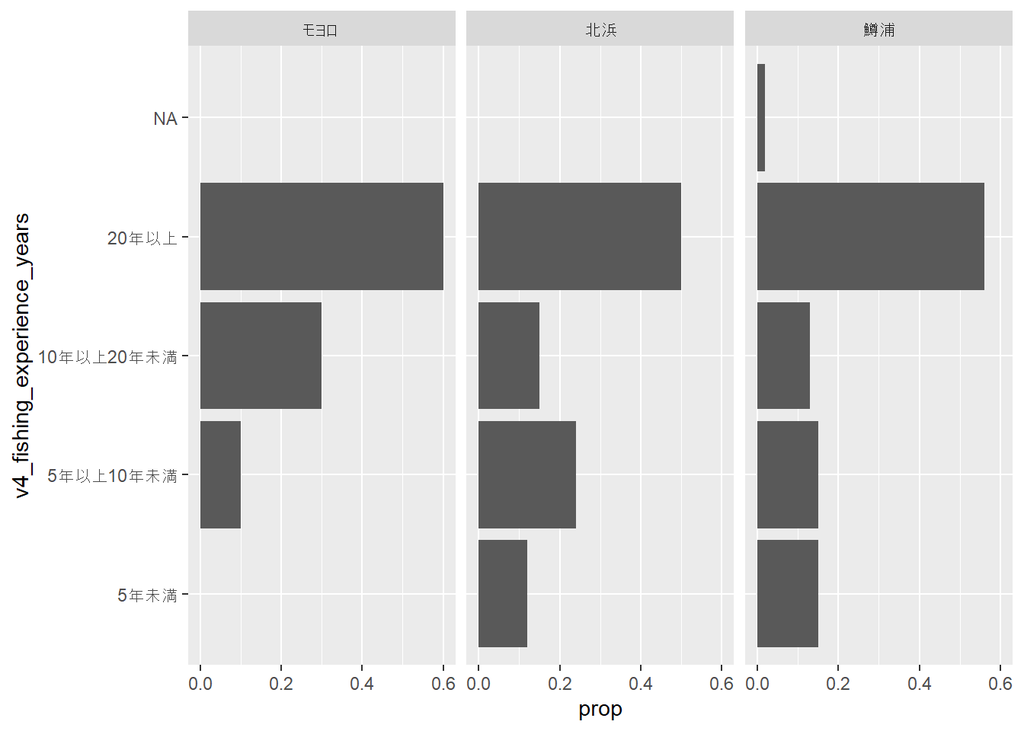

調査地によって釣り歴が異なるという感じではない。

# 今シーズン釣り日数(v5_fishing_days_this_season)

```
## # A tibble: 4 × 3
##   v5_fishing_days_this_season     n  prop
##   <ord>                       <int> <dbl>
## 1 5日未満                        63  0.64
## 2 5日以上10日未満                13  0.13
## 3 10日以上30日未満               15  0.15
## 4 <NA>                            7  0.07
```

50日以上はゼロ。あくまで「今シーズン」だからかな。

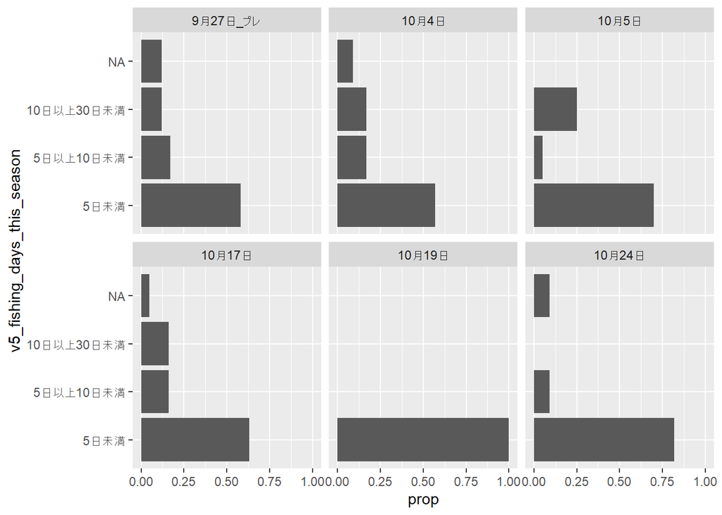

調査日が後になるほど5日未満が減るのでは…と思ったがそんな傾向はみられない。

# 昨シーズン釣り日数(v6_fishing_days_last_season)

```
## # A tibble: 6 × 3
##   v6_fishing_days_last_season     n  prop
##   <ord>                       <int> <dbl>
## 1 昨シーズンは来ていない         13  0.13
## 2 5日未満                        41  0.42
## 3 5日以上10日未満                16  0.16
## 4 10日以上30日未満               16  0.16
## 5 50日以上                        5  0.05
## 6 <NA>                            7  0.07
```

昨シーズンでみても5日未満が最も多い。

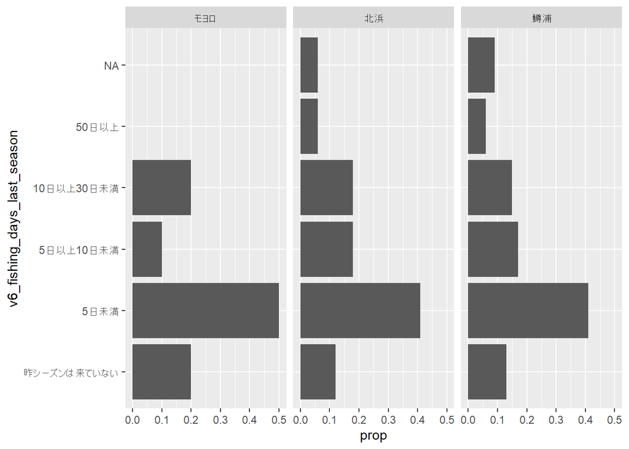

モヨロは昨シーズン来ていない人、5日未満の人がやや多め。50日以上はゼロ。ビギナー向けの釣り場なのかもしれない（サンプル数が少ないのであまり積極的なことはいえないが）。